# Estadística Inferencial IS-241 — Propuesta Aplicativa Global

UNADECA | Escuela de Ingeniería en Sistemas

26 de marzo de 2026

> **Profesor:** Dodanim Castillo Aráuz | **Materia:** IS-241 Estadística Inferencial  
> **Instrucciones:** Esta propuesta aplicativa cubre TODOS los temas del cuatrimestre y permite resolver cualquier caso modificando los parámetros de cada sección.

# 1 REPASO DE CONCEPTOS — ESTADÍSTICA DESCRIPTIVA

## 1.1 Definiciones clave

- **Variable aleatoria discreta:** Toma valores contables (ej. número de errores en código).
- **Variable aleatoria continua:** Toma cualquier valor en un intervalo (ej. tiempo de respuesta de un servidor).

## 1.2 Cálculo de medidas descriptivas

Modifique el vector `datos` con sus propios valores:

```r
# ─── DATOS DE ENTRADA — modifique aquí ───────────────────────
datos <- c(12, 15, 14, 10, 18, 20, 14, 16, 15, 13, 17, 11)

# ─── CÁLCULOS ─────────────────────────────────────────────────
n       <- length(datos)
media   <- mean(datos)
mediana <- median(datos)
moda_tab <- table(datos)
moda    <- as.numeric(names(moda_tab)[moda_tab == max(moda_tab)])
var_m   <- var(datos)          # varianza muestral
sd_m    <- sd(datos)           # desv. estándar muestral
var_p   <- var(datos)*(n-1)/n  # varianza poblacional
sd_p    <- sqrt(var_p)
cv      <- sd_m / media * 100  # coeficiente de variación
rango   <- max(datos) - min(datos)
q1      <- quantile(datos, 0.25)
q3      <- quantile(datos, 0.75)
iqr     <- q3 - q1

# Asimetría de Pearson
asimetria <- 3 * (media - mediana) / sd_m

# ─── RESULTADOS ───────────────────────────────────────────────
cat("════════════════════════════════════════\n")
```

```
## ════════════════════════════════════════
```

```r
cat("  ESTADÍSTICA DESCRIPTIVA\n")
```

```
##   ESTADÍSTICA DESCRIPTIVA
```

```r
cat("════════════════════════════════════════\n")
```

```
## ════════════════════════════════════════
```

```r
cat(sprintf("  n = %d observaciones\n", n))
```

```
##   n = 12 observaciones
```

```r
cat(sprintf("  Mínimo / Máximo:  %.2f / %.2f\n", min(datos), max(datos)))
```

```
##   Mínimo / Máximo:  10.00 / 20.00
```

```r
cat(sprintf("  Rango:            %.4f\n", rango))
```

```
##   Rango:            10.0000
```

```r
cat("────────────────────────────────────────\n")
cat("  TENDENCIA CENTRAL\n")
```

```
##   TENDENCIA CENTRAL
```

```r
cat(sprintf("  Media (X̄):        %.4f\n", media))
```

```
##   Media (X̄):        14.5833
```

```r
cat(sprintf("  Mediana:          %.4f\n", mediana))
```

```
##   Mediana:          14.5000
```

```r
cat(sprintf("  Moda:             %s\n", paste(moda, collapse=", ")))
```

```
##   Moda:             14, 15
```

```r
cat("────────────────────────────────────────\n")
cat("  DISPERSIÓN\n")
```

```
##   DISPERSIÓN
```

```r
cat(sprintf("  Varianza muestral (s²):     %.4f\n", var_m))
```

```
##   Varianza muestral (s²):     8.4470
```

```r
cat(sprintf("  Desv. est. muestral (s):    %.4f\n", sd_m))
```

```
##   Desv. est. muestral (s):    2.9064
```

```r
cat(sprintf("  Varianza poblacional (σ²):  %.4f\n", var_p))
```

```
##   Varianza poblacional (σ²):  7.7431
```

```r
cat(sprintf("  Desv. est. poblacional (σ): %.4f\n", sd_p))
```

```
##   Desv. est. poblacional (σ): 2.7826
```

```r
cat(sprintf("  Coef. variación (CV%%):      %.2f%%\n", cv))
```

```
##   Coef. variación (CV%):      19.93%
```

```r
cat("────────────────────────────────────────\n")
cat("  POSICIÓN\n")
```

```
##   POSICIÓN
```

```r
cat(sprintf("  Q1 (25%%): %.4f | Q3 (75%%): %.4f | IQR: %.4f\n", q1, q3, iqr))
```

```
##   Q1 (25%): 12.7500 | Q3 (75%): 16.2500 | IQR: 3.5000
```

```r
cat("────────────────────────────────────────\n")
cat("  ASIMETRÍA (Coef. Pearson)\n")
```

```
##   ASIMETRÍA (Coef. Pearson)
```

```r
cat(sprintf("  Asimetría: %.4f → %s\n", asimetria,
    ifelse(abs(asimetria)<0.1,"Simétrica",
    ifelse(asimetria>0,"Asimétrica (+) cola derecha","Asimétrica (-) cola izquierda"))))
```

```
##   Asimetría: 0.0860 → Simétrica
```

```r
cat("════════════════════════════════════════\n")
```

```
## ════════════════════════════════════════
```

## 1.3 Gráficos descriptivos

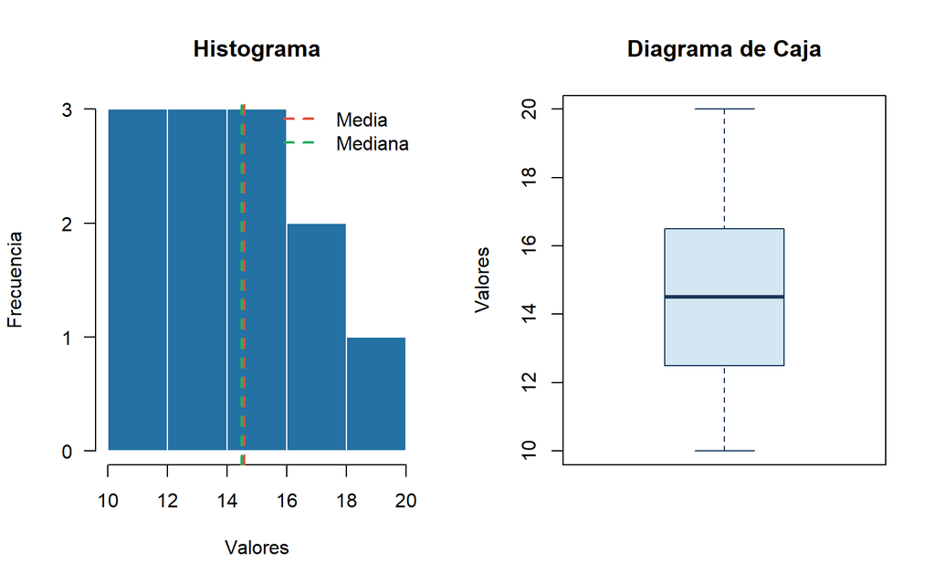

```r
par(mfrow=c(1,2))

# Histograma
hist(datos, col="#2471a3", border="white",
     main="Histograma", xlab="Valores", ylab="Frecuencia",
     las=1)
abline(v=media,   col="#e74c3c", lwd=2, lty=2)
abline(v=mediana, col="#27ae60", lwd=2, lty=2)
legend("topright", legend=c("Media","Mediana"),
       col=c("#e74c3c","#27ae60"), lwd=2, lty=2, bty="n")

# Boxplot
boxplot(datos, col="#d4e6f1", border="#1a3a5c",
        main="Diagrama de Caja", ylab="Valores",
        notch=FALSE)
```

# 2 DISTRIBUCIÓN BINOMIAL

## 2.1 Teoría

Una distribución binomial describe el número de éxitos en **n ensayos independientes**, donde la probabilidad de éxito en cada ensayo es **p** constante.

**Propiedades:** Solo dos resultados posibles | p constante | Ensayos independientes | Mutuamente excluyentes

$$P(X=x) = \binom{n}{x} p^x q^{n-x} =
\frac{n!}{x!(n-x)!} \cdot p^x \cdot q^{n-x}$$

$$\mu = n \cdot p \qquad \sigma^2 = n
\cdot p \cdot q \qquad \sigma = \sqrt{n \cdot p \cdot q}$$

## 2.2 Ejemplo resuelto y calculador

```r
# ─── PARÁMETROS — modifique aquí ─────────────────────────────
n <- 12      # Número de ensayos
p <- 0.80    # Probabilidad de éxito
x <- 7       # Número de éxitos de interés

# ─── CÁLCULOS ─────────────────────────────────────────────────
q      <- 1 - p
mu_bin <- n * p
var_bin <- n * p * q
sd_bin  <- sqrt(var_bin)

# Tipos de probabilidad
P_igual        <- dbinom(x, n, p)
P_menor_igual  <- pbinom(x, n, p)
P_mayor_igual  <- 1 - pbinom(x-1, n, p)
P_menor        <- pbinom(x-1, n, p)
P_mayor        <- 1 - pbinom(x, n, p)

# Tabla completa
xs     <- 0:n
probs  <- dbinom(xs, n, p)
acum   <- pbinom(xs, n, p)

cat("════════════════════════════════════════\n")
```

```
## ════════════════════════════════════════
```

```r
cat(sprintf("  DISTRIBUCIÓN BINOMIAL B(n=%d, p=%.2f)\n", n, p))
```

```
##   DISTRIBUCIÓN BINOMIAL B(n=12, p=0.80)
```

```r
cat("════════════════════════════════════════\n")
```

```
## ════════════════════════════════════════
```

```r
cat(sprintf("  q = 1-p = %.4f\n", q))
```

```
##   q = 1-p = 0.2000
```

```r
cat(sprintf("  μ = n·p = %d × %.2f = %.4f\n", n, p, mu_bin))
```

```
##   μ = n·p = 12 × 0.80 = 9.6000
```

```r
cat(sprintf("  σ² = n·p·q = %.4f\n", var_bin))
```

```
##   σ² = n·p·q = 1.9200
```

```r
cat(sprintf("  σ = √(n·p·q) = %.4f\n", sd_bin))
```

```
##   σ = √(n·p·q) = 1.3856
```

```r
cat("────────────────────────────────────────\n")
cat(sprintf("  P(X = %d)  = %.6f\n", x, P_igual))
```

```
##   P(X = 7)  = 0.053150
```

```r
cat(sprintf("  P(X ≤ %d)  = %.6f\n", x, P_menor_igual))
```

```
##   P(X ≤ 7)  = 0.072555
```

```r
cat(sprintf("  P(X ≥ %d)  = %.6f\n", x, P_mayor_igual))
```

```
##   P(X ≥ 7)  = 0.980595
```

```r
cat(sprintf("  P(X < %d)  = %.6f\n", x, P_menor))
```

```
##   P(X < 7)  = 0.019405
```

```r
cat(sprintf("  P(X > %d)  = %.6f\n", x, P_mayor))
```

```
##   P(X > 7)  = 0.927445
```

```r
cat("────────────────────────────────────────\n")
cat("  Intervalo usual (μ ± 2σ):\n")
```

```
##   Intervalo usual (μ ± 2σ):
```

```r
cat(sprintf("  [%.2f,  %.2f]\n", max(0,mu_bin-2*sd_bin), min(n,mu_bin+2*sd_bin)))
```

```
##   [6.83,  12.00]
```

```r
cat("════════════════════════════════════════\n")
```

```
## ════════════════════════════════════════
```

```r
# Tabla de distribución
tabla_bin <- data.frame(
  x       = xs,
  "P(X=x)"  = round(probs, 6),
  "P(X≤x)"  = round(acum, 6),
  "P(X≥x)"  = round(1 - pbinom(xs-1, n, p), 6),
  check.names = FALSE
)
knitr::kable(tabla_bin, caption = "Tabla de distribución binomial completa",
             align = "cccc")
```

Tabla de distribución binomial completa

| x | P(X=x) | P(X≤x) | P(X≥x) |
| --- | --- | --- | --- |
| 0 | 0.000000 | 0.000000 | 1.000000 |
| 1 | 0.000000 | 0.000000 | 1.000000 |
| 2 | 0.000004 | 0.000005 | 1.000000 |
| 3 | 0.000058 | 0.000062 | 0.999995 |
| 4 | 0.000519 | 0.000581 | 0.999938 |
| 5 | 0.003322 | 0.003903 | 0.999419 |
| 6 | 0.015502 | 0.019405 | 0.996097 |
| 7 | 0.053150 | 0.072555 | 0.980595 |
| 8 | 0.132876 | 0.205431 | 0.927445 |
| 9 | 0.236223 | 0.441654 | 0.794569 |
| 10 | 0.283468 | 0.725122 | 0.558346 |
| 11 | 0.206158 | 0.931281 | 0.274878 |
| 12 | 0.068719 | 1.000000 | 0.068719 |

## 2.3 Gráfico de la distribución

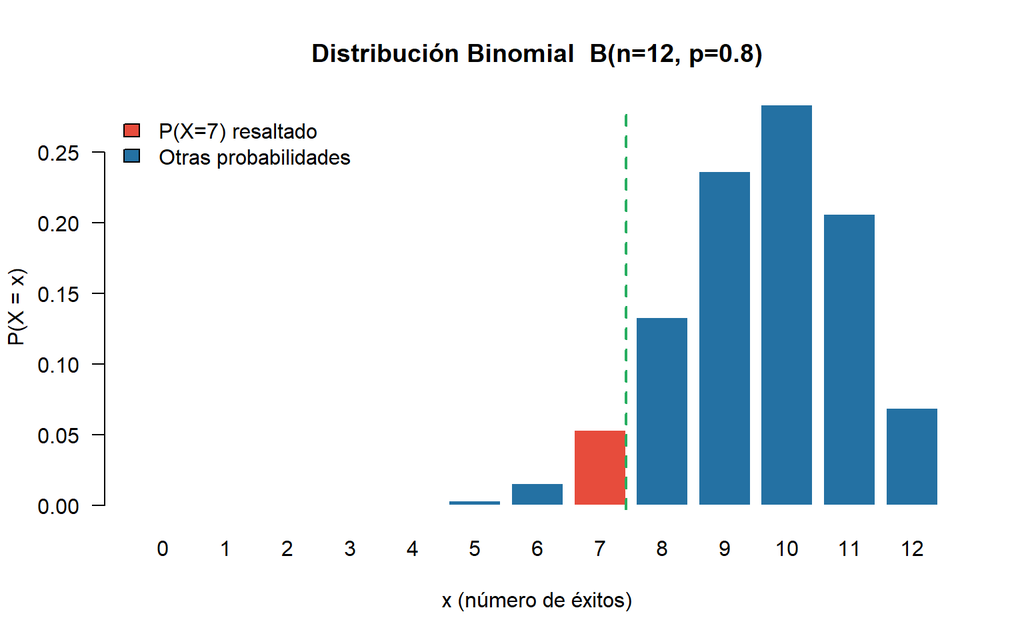

```r
colores <- ifelse(xs == x, "#e74c3c", "#2471a3")
barplot(probs, names.arg = xs, col = colores, border = "white",
        main = paste0("Distribución Binomial  B(n=", n, ", p=", p, ")"),
        xlab = "x (número de éxitos)", ylab = "P(X = x)",
        las = 1)
legend("topleft", legend = c(paste0("P(X=",x,") resaltado"), "Otras probabilidades"),
       fill = c("#e74c3c","#2471a3"), bty="n")
abline(v = (mu_bin/n*n), col = "#27ae60", lty = 2, lwd = 2)
```

# 3 DISTRIBUCIÓN NORMAL

## 3.1 Teoría

La distribución normal (campana de Gauss) es continua y simétrica alrededor de μ.

$$f(x) = \frac{1}{\sigma\sqrt{2\pi}}
e^{-\frac{(x-\mu)^2}{2\sigma^2}}$$

**Estandarización:**
$$Z =
\frac{x - \mu}{\sigma}$$

## 3.2 Calculador: P(X ≤ x), P(X ≥ x), P(a ≤ X ≤ b)

```r
# ─── PARÁMETROS — modifique aquí ─────────────────────────────
mu    <- 100    # Media poblacional
sigma <- 15     # Desviación estándar

# Caso 1: P(X ≤ x)
x1 <- 110
z1 <- (x1 - mu) / sigma
P1 <- pnorm(z1)

# Caso 2: P(X ≥ x)
x2 <- 85
z2 <- (x2 - mu) / sigma
P2 <- 1 - pnorm(z2)

# Caso 3: P(a ≤ X ≤ b)
a <- 90; b <- 115
za <- (a - mu)/sigma; zb <- (b - mu)/sigma
P3 <- pnorm(zb) - pnorm(za)

# Caso 4: Valor x dado probabilidad (cuantil)
prob_buscada <- 0.95
z_cuantil <- qnorm(prob_buscada)
x_cuantil  <- mu + z_cuantil * sigma

cat("════════════════════════════════════════\n")
```

```
## ════════════════════════════════════════
```

```r
cat(sprintf("  DISTRIBUCIÓN NORMAL N(μ=%.1f, σ=%.1f)\n", mu, sigma))
```

```
##   DISTRIBUCIÓN NORMAL N(μ=100.0, σ=15.0)
```

```r
cat("════════════════════════════════════════\n")
```

```
## ════════════════════════════════════════
```

```r
cat(sprintf("  Caso 1: P(X ≤ %.1f)\n", x1))
```

```
##   Caso 1: P(X ≤ 110.0)
```

```r
cat(sprintf("    Z = (%.1f-%.1f)/%.1f = %.4f\n", x1, mu, sigma, z1))
```

```
##     Z = (110.0-100.0)/15.0 = 0.6667
```

```r
cat(sprintf("    P(X ≤ %.1f) = %.6f = %.2f%%\n\n", x1, P1, P1*100))
```

```
##     P(X ≤ 110.0) = 0.747507 = 74.75%
```

```r
cat(sprintf("  Caso 2: P(X ≥ %.1f)\n", x2))
```

```
##   Caso 2: P(X ≥ 85.0)
```

```r
cat(sprintf("    Z = (%.1f-%.1f)/%.1f = %.4f\n", x2, mu, sigma, z2))
```

```
##     Z = (85.0-100.0)/15.0 = -1.0000
```

```r
cat(sprintf("    P(X ≥ %.1f) = %.6f = %.2f%%\n\n", x2, P2, P2*100))
```

```
##     P(X ≥ 85.0) = 0.841345 = 84.13%
```

```r
cat(sprintf("  Caso 3: P(%.1f ≤ X ≤ %.1f)\n", a, b))
```

```
##   Caso 3: P(90.0 ≤ X ≤ 115.0)
```

```r
cat(sprintf("    Za=%.4f, Zb=%.4f\n", za, zb))
```

```
##     Za=-0.6667, Zb=1.0000
```

```r
cat(sprintf("    Probabilidad = %.6f = %.2f%%\n\n", P3, P3*100))
```

```
##     Probabilidad = 0.588852 = 58.89%
```

```r
cat(sprintf("  Caso 4: x tal que P(X ≤ x) = %.2f\n", prob_buscada))
```

```
##   Caso 4: x tal que P(X ≤ x) = 0.95
```

```r
cat(sprintf("    Z = %.4f → x = μ+Z·σ = %.4f\n", z_cuantil, x_cuantil))
```

```
##     Z = 1.6449 → x = μ+Z·σ = 124.6728
```

```r
cat("════════════════════════════════════════\n")
```

```
## ════════════════════════════════════════
```

## 3.3 Gráficos — Áreas bajo la curva normal

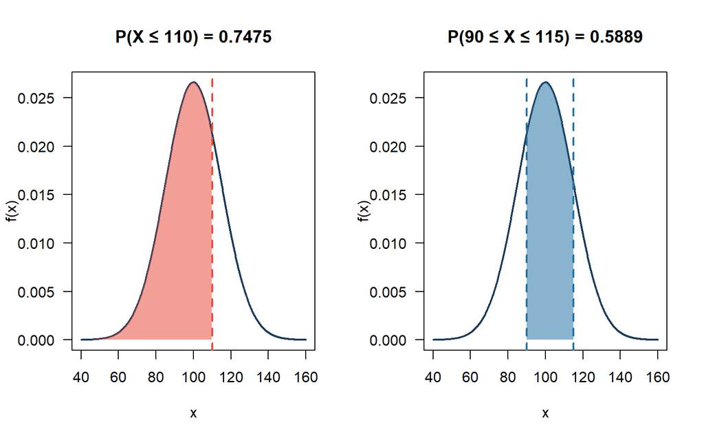

```r
par(mfrow=c(1,2))

x_seq <- seq(mu - 4*sigma, mu + 4*sigma, length.out=1000)
y_seq <- dnorm(x_seq, mu, sigma)

# Gráfico 1: P(X ≤ x1)
plot(x_seq, y_seq, type="l", lwd=2, col="#1a3a5c",
     main=paste0("P(X ≤ ", x1, ") = ", round(P1,4)),
     xlab="x", ylab="f(x)", las=1)
x_fill <- x_seq[x_seq <= x1]
y_fill <- dnorm(x_fill, mu, sigma)
polygon(c(x_fill, rev(x_fill)), c(y_fill, rep(0,length(y_fill))),
        col="#e74c3c88", border=NA)
abline(v=x1, col="#e74c3c", lwd=2, lty=2)

# Gráfico 2: P(a ≤ X ≤ b)
plot(x_seq, y_seq, type="l", lwd=2, col="#1a3a5c",
     main=paste0("P(", a, " ≤ X ≤ ", b, ") = ", round(P3,4)),
     xlab="x", ylab="f(x)", las=1)
x_fill2 <- x_seq[x_seq >= a & x_seq <= b]
y_fill2 <- dnorm(x_fill2, mu, sigma)
polygon(c(x_fill2, rev(x_fill2)), c(y_fill2, rep(0,length(y_fill2))),
        col="#2471a388", border=NA)
abline(v=c(a,b), col="#2471a3", lwd=2, lty=2)
```

# 4 PRUEBA DE HIPÓTESIS

## 4.1 Aspectos básicos

| Concepto | Descripción |
| --- | --- |
| **H₀ (hipótesis nula)** | Lo que se desea probar/rechazar |
| **H₁ (hipótesis alternativa)** | Contradice H₀ |
| **Error Tipo I (α)** | Rechazar H₀ siendo verdadera |
| **Error Tipo II (β)** | Aceptar H₀ siendo falsa |
| **p-valor** | Probabilidad de obtener el resultado si H₀ fuera cierta |

**Regla de decisión:** Si |Z_calc| > Z_crítico → Rechazar H₀

## 4.2 Caso 1 — Prueba Z para una media (σ conocida)

$$Z = \frac{\bar{X} -
\mu_0}{\sigma_{\bar{x}}} \qquad \text{donde} \quad \sigma_{\bar{x}} =
\frac{\sigma}{\sqrt{n}}$$

```r
# ─── PARÁMETROS — modifique aquí ─────────────────────────────
mu_0  <- 100    # Media hipotética (H₀)
xbar  <- 102    # Media muestral
sigma_z <- 10   # Desviación estándar poblacional (conocida)
n_z   <- 400    # Tamaño de muestra
alfa_z <- 0.05  # Nivel de significación
cola_z <- "dos" # "dos", "derecha", "izquierda"

# ─── CÁLCULOS ─────────────────────────────────────────────────
sigma_xbar <- sigma_z / sqrt(n_z)
Z_calc     <- (xbar - mu_0) / sigma_xbar
Z_crit     <- switch(cola_z,
  "dos"      = qnorm(1 - alfa_z/2),
  "derecha"  = qnorm(1 - alfa_z),
  "izquierda"= qnorm(alfa_z)
)
p_valor_z <- switch(cola_z,
  "dos"      = 2 * pnorm(-abs(Z_calc)),
  "derecha"  = 1 - pnorm(Z_calc),
  "izquierda"= pnorm(Z_calc)
)
H1_texto <- switch(cola_z,
  "dos"="μ ≠ μ₀","derecha"="μ > μ₀","izquierda"="μ < μ₀")
decision_z <- switch(cola_z,
  "dos"      = if(abs(Z_calc) > Z_crit) "RECHAZAR H₀" else "NO RECHAZAR H₀",
  "derecha"  = if(Z_calc > Z_crit)      "RECHAZAR H₀" else "NO RECHAZAR H₀",
  "izquierda"= if(Z_calc < Z_crit)      "RECHAZAR H₀" else "NO RECHAZAR H₀"
)

cat("════════════════════════════════════════\n")
```

```
## ════════════════════════════════════════
```

```r
cat("  PRUEBA Z — UNA MEDIA (σ conocida)\n")
```

```
##   PRUEBA Z — UNA MEDIA (σ conocida)
```

```r
cat("════════════════════════════════════════\n")
```

```
## ════════════════════════════════════════
```

```r
cat(sprintf("  H₀: μ = %.4f\n", mu_0))
```

```
##   H₀: μ = 100.0000
```

```r
cat(sprintf("  H₁: %s\n", H1_texto))
```

```
##   H₁: μ ≠ μ₀
```

```r
cat(sprintf("  α = %.3f | Tipo de prueba: %s\n", alfa_z, cola_z))
```

```
##   α = 0.050 | Tipo de prueba: dos
```

```r
cat("────────────────────────────────────────\n")
cat(sprintf("  σ_x̄ = σ/√n = %.4f/√%d = %.6f\n", sigma_z, n_z, sigma_xbar))
```

```
##   σ_x̄ = σ/√n = 10.0000/√400 = 0.500000
```

```r
cat(sprintf("  Z_calculado = (%.4f - %.4f) / %.6f = %.4f\n",
            xbar, mu_0, sigma_xbar, Z_calc))
```

```
##   Z_calculado = (102.0000 - 100.0000) / 0.500000 = 4.0000
```

```r
cat(sprintf("  Z_crítico   = ±%.4f\n", abs(Z_crit)))
```

```
##   Z_crítico   = ±1.9600
```

```r
cat(sprintf("  p-valor     = %.6f\n", p_valor_z))
```

```
##   p-valor     = 0.000063
```

```r
cat("────────────────────────────────────────\n")
cat(sprintf("  DECISIÓN: %s\n", decision_z))
```

```
##   DECISIÓN: RECHAZAR H₀
```

```r
cat("════════════════════════════════════════\n")
```

```
## ════════════════════════════════════════
```

## 4.3 Gráfico — Región de rechazo (prueba Z)

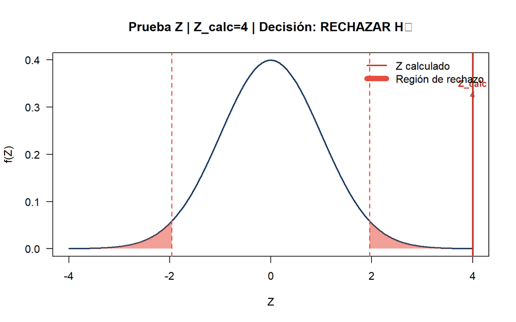

```r
x_range <- seq(-4, 4, 0.01)
y_range <- dnorm(x_range)
plot(x_range, y_range, type="l", lwd=2, col="#1a3a5c",
     main=paste0("Prueba Z | Z_calc=",round(Z_calc,4)," | Decisión: ",decision_z),
     xlab="Z", ylab="f(Z)", las=1)

# Región de rechazo
if(cola_z == "dos") {
  x_rej_r <- x_range[x_range >= abs(Z_crit)]
  x_rej_l <- x_range[x_range <= -abs(Z_crit)]
  polygon(c(x_rej_r, rev(x_rej_r)), c(dnorm(x_rej_r), rep(0,length(x_rej_r))),
          col="#e74c3c88", border=NA)
  polygon(c(x_rej_l, rev(x_rej_l)), c(dnorm(x_rej_l), rep(0,length(x_rej_l))),
          col="#e74c3c88", border=NA)
  abline(v=c(-abs(Z_crit), abs(Z_crit)), col="#e74c3c", lty=2, lwd=1.5)
} else if (cola_z == "derecha") {
  x_rej <- x_range[x_range >= Z_crit]
  polygon(c(x_rej, rev(x_rej)), c(dnorm(x_rej), rep(0,length(x_rej))),
          col="#e74c3c88", border=NA)
  abline(v=Z_crit, col="#e74c3c", lty=2, lwd=1.5)
} else {
  x_rej <- x_range[x_range <= Z_crit]
  polygon(c(x_rej, rev(x_rej)), c(dnorm(x_rej), rep(0,length(x_rej))),
          col="#e74c3c88", border=NA)
  abline(v=Z_crit, col="#e74c3c", lty=2, lwd=1.5)
}
abline(v=Z_calc, col=ifelse(decision_z=="RECHAZAR H₀","#c0392b","#27ae60"),
       lwd=2.5)
text(Z_calc, max(y_range)*0.85, paste0("Z_calc\n",round(Z_calc,4)),
     col=ifelse(decision_z=="RECHAZAR H₀","#c0392b","#27ae60"), font=2, cex=0.85)
legend("topright", legend=c("Z calculado","Región de rechazo"),
       col=c(ifelse(decision_z=="RECHAZAR H₀","#c0392b","#27ae60"),"#e74c3c"),
       lwd=c(2,8), bty="n")
```

$$t = \frac{\bar{X} - \mu_0}{s/\sqrt{n}}
\qquad gl = n-1$$

```r
# ─── PARÁMETROS — modifique aquí ─────────────────────────────
mu_0t  <- 104   # Media hipotética H₀
xbar_t <- 102   # Media muestral
s_t    <- 8     # Desviación estándar muestral
n_t    <- 36    # Tamaño de muestra (puede ser <30 o ≥30)
alfa_t <- 0.05  # Nivel de significación
cola_t <- "dos" # "dos", "derecha", "izquierda"

# ─── CÁLCULOS ─────────────────────────────────────────────────
gl_t    <- n_t - 1
se_t    <- s_t / sqrt(n_t)
t_calc  <- (xbar_t - mu_0t) / se_t
t_crit  <- switch(cola_t,
  "dos"      = qt(1-alfa_t/2, gl_t),
  "derecha"  = qt(1-alfa_t, gl_t),
  "izquierda"= qt(alfa_t, gl_t)
)
p_val_t <- switch(cola_t,
  "dos"      = 2*pt(-abs(t_calc), gl_t),
  "derecha"  = 1-pt(t_calc, gl_t),
  "izquierda"= pt(t_calc, gl_t)
)
decision_t <- switch(cola_t,
  "dos"      = if(abs(t_calc)>t_crit) "RECHAZAR H₀" else "NO RECHAZAR H₀",
  "derecha"  = if(t_calc>t_crit)      "RECHAZAR H₀" else "NO RECHAZAR H₀",
  "izquierda"= if(t_calc<t_crit)      "RECHAZAR H₀" else "NO RECHAZAR H₀"
)

cat("════════════════════════════════════════\n")
```

```
## ════════════════════════════════════════
```

```r
cat("  PRUEBA t — UNA MEDIA (σ desconocida)\n")
```

```
##   PRUEBA t — UNA MEDIA (σ desconocida)
```

```r
cat("════════════════════════════════════════\n")
```

```
## ════════════════════════════════════════
```

```r
cat(sprintf("  H₀: μ = %.4f\n", mu_0t))
```

```
##   H₀: μ = 104.0000
```

```r
cat(sprintf("  α = %.3f | gl = n-1 = %d\n", alfa_t, gl_t))
```

```
##   α = 0.050 | gl = n-1 = 35
```

```r
cat(sprintf("  SE = s/√n = %.4f/√%d = %.6f\n", s_t, n_t, se_t))
```

```
##   SE = s/√n = 8.0000/√36 = 1.333333
```

```r
cat(sprintf("  t_calculado = %.4f\n", t_calc))
```

```
##   t_calculado = -1.5000
```

```r
cat(sprintf("  t_crítico   = ±%.4f  (gl=%d)\n", abs(t_crit), gl_t))
```

```
##   t_crítico   = ±2.0301  (gl=35)
```

```r
cat(sprintf("  p-valor     = %.6f\n", p_val_t))
```

```
##   p-valor     = 0.142582
```

```r
cat(sprintf("  DECISIÓN: %s\n", decision_t))
```

```
##   DECISIÓN: NO RECHAZAR H₀
```

```r
cat("════════════════════════════════════════\n")
```

```
## ════════════════════════════════════════
```

## 4.5 Caso 3 — Prueba para una proporción

$$Z = \frac{p - P}{\sigma_p} \qquad
\sigma_p = \sqrt{\frac{P \cdot Q}{n}}$$

```r
# ─── PARÁMETROS — modifique aquí ─────────────────────────────
P_pob   <- 0.32   # Proporción poblacional H₀
p_mues  <- 0.26   # Proporción muestral observada
n_pr    <- 400    # Tamaño de muestra
alfa_pr <- 0.05   # Nivel de significación
cola_pr <- "dos"  # "dos", "derecha", "izquierda"

# ─── CÁLCULOS ─────────────────────────────────────────────────
Q_pob    <- 1 - P_pob
sigma_p  <- sqrt(P_pob * Q_pob / n_pr)
Z_pr     <- (p_mues - P_pob) / sigma_p
Z_crit_pr <- switch(cola_pr,
  "dos"="dos","derecha"=qnorm(1-alfa_pr),"izquierda"=qnorm(alfa_pr))
Z_crit_pr_val <- switch(cola_pr,
  "dos"=qnorm(1-alfa_pr/2),"derecha"=qnorm(1-alfa_pr),"izquierda"=qnorm(alfa_pr))
p_val_pr <- switch(cola_pr,
  "dos"=2*pnorm(-abs(Z_pr)),"derecha"=1-pnorm(Z_pr),"izquierda"=pnorm(Z_pr))
decision_pr <- switch(cola_pr,
  "dos"      = if(abs(Z_pr)>Z_crit_pr_val) "RECHAZAR H₀" else "NO RECHAZAR H₀",
  "derecha"  = if(Z_pr>Z_crit_pr_val)      "RECHAZAR H₀" else "NO RECHAZAR H₀",
  "izquierda"= if(Z_pr<Z_crit_pr_val)      "RECHAZAR H₀" else "NO RECHAZAR H₀"
)

cat("════════════════════════════════════════\n")
```

```
## ════════════════════════════════════════
```

```r
cat("  PRUEBA Z — UNA PROPORCIÓN\n")
```

```
##   PRUEBA Z — UNA PROPORCIÓN
```

```r
cat("════════════════════════════════════════\n")
```

```
## ════════════════════════════════════════
```

```r
cat(sprintf("  H₀: P = %.4f | Q = %.4f\n", P_pob, Q_pob))
```

```
##   H₀: P = 0.3200 | Q = 0.6800
```

```r
cat(sprintf("  p (muestral) = %.4f | n = %d\n", p_mues, n_pr))
```

```
##   p (muestral) = 0.2600 | n = 400
```

```r
cat(sprintf("  σ_p = √(P·Q/n) = %.6f\n", sigma_p))
```

```
##   σ_p = √(P·Q/n) = 0.023324
```

```r
cat(sprintf("  Z_calculado = (%.4f - %.4f) / %.6f = %.4f\n",
            p_mues, P_pob, sigma_p, Z_pr))
```

```
##   Z_calculado = (0.2600 - 0.3200) / 0.023324 = -2.5725
```

```r
cat(sprintf("  Z_crítico   = ±%.4f\n", abs(Z_crit_pr_val)))
```

```
##   Z_crítico   = ±1.9600
```

```r
cat(sprintf("  p-valor     = %.6f\n", p_val_pr))
```

```
##   p-valor     = 0.010097
```

```r
cat(sprintf("  DECISIÓN: %s\n", decision_pr))
```

```
##   DECISIÓN: RECHAZAR H₀
```

```r
cat("════════════════════════════════════════\n")
```

```
## ════════════════════════════════════════
```

## 4.6 Caso 4 — Diferencia de medias (dos muestras)

$$Z = \frac{\bar{X}_1 -
\bar{X}_2}{\sigma_{\Delta\bar{x}}} \qquad \sigma_{\Delta\bar{x}} =
\sqrt{\frac{s_1^2}{n_1} + \frac{s_2^2}{n_2}}$$

```r
# ─── PARÁMETROS — modifique aquí ─────────────────────────────
x1_dm <- 68; s1_dm <- 12; n1_dm <- 40
x2_dm <- 65; s2_dm <- 14; n2_dm <- 50
alfa_dm <- 0.05; cola_dm <- "dos"

sigma_delta <- sqrt(s1_dm^2/n1_dm + s2_dm^2/n2_dm)
Z_dm   <- (x1_dm - x2_dm) / sigma_delta
Zcr_dm <- switch(cola_dm,"dos"=qnorm(1-alfa_dm/2),"derecha"=qnorm(1-alfa_dm),"izquierda"=qnorm(alfa_dm))
pv_dm  <- switch(cola_dm,"dos"=2*pnorm(-abs(Z_dm)),"derecha"=1-pnorm(Z_dm),"izquierda"=pnorm(Z_dm))
dec_dm <- switch(cola_dm,
  "dos"      = if(abs(Z_dm)>Zcr_dm) "RECHAZAR H₀" else "NO RECHAZAR H₀",
  "derecha"  = if(Z_dm>Zcr_dm)      "RECHAZAR H₀" else "NO RECHAZAR H₀",
  "izquierda"= if(Z_dm<Zcr_dm)      "RECHAZAR H₀" else "NO RECHAZAR H₀"
)

cat("════════════════════════════════════════\n")
```

```
## ════════════════════════════════════════
```

```r
cat("  PRUEBA Z — DIFERENCIA DE MEDIAS\n")
```

```
##   PRUEBA Z — DIFERENCIA DE MEDIAS
```

```r
cat("════════════════════════════════════════\n")
```

```
## ════════════════════════════════════════
```

```r
cat(sprintf("  Muestra 1: X̄₁=%.2f, s₁=%.2f, n₁=%d\n", x1_dm, s1_dm, n1_dm))
```

```
##   Muestra 1: X̄₁=68.00, s₁=12.00, n₁=40
```

```r
cat(sprintf("  Muestra 2: X̄₂=%.2f, s₂=%.2f, n₂=%d\n", x2_dm, s2_dm, n2_dm))
```

```
##   Muestra 2: X̄₂=65.00, s₂=14.00, n₂=50
```

```r
cat(sprintf("  σ_ΔX̄ = √(s₁²/n₁+s₂²/n₂) = %.6f\n", sigma_delta))
```

```
##   σ_ΔX̄ = √(s₁²/n₁+s₂²/n₂) = 2.742262
```

```r
cat(sprintf("  Z_calculado = %.4f\n", Z_dm))
```

```
##   Z_calculado = 1.0940
```

```r
cat(sprintf("  Z_crítico   = ±%.4f\n", abs(Zcr_dm)))
```

```
##   Z_crítico   = ±1.9600
```

```r
cat(sprintf("  p-valor     = %.6f\n", pv_dm))
```

```
##   p-valor     = 0.273960
```

```r
cat(sprintf("  DECISIÓN: %s\n", dec_dm))
```

```
##   DECISIÓN: NO RECHAZAR H₀
```

```r
cat("════════════════════════════════════════\n")
```

```
## ════════════════════════════════════════
```

## 4.7 Caso 5 — Diferencia de proporciones

$$Z = \frac{p_1 - p_2}{\sigma_{\Delta p}}
\qquad \sigma_{\Delta p} =
\sqrt{\bar{p}\bar{q}\left(\frac{1}{n_1}+\frac{1}{n_2}\right)}$$

```r
# ─── PARÁMETROS — modifique aquí ─────────────────────────────
p1_dp <- 0.65; n1_dp <- 200
p2_dp <- 0.60; n2_dp <- 300
alfa_dp <- 0.02; cola_dp <- "dos"

p_pond <- (p1_dp*n1_dp + p2_dp*n2_dp)/(n1_dp+n2_dp)
q_pond <- 1 - p_pond
sigma_dp <- sqrt(p_pond*q_pond*(1/n1_dp + 1/n2_dp))
Z_dp   <- (p1_dp - p2_dp) / sigma_dp
Zcr_dp <- switch(cola_dp,"dos"=qnorm(1-alfa_dp/2),"derecha"=qnorm(1-alfa_dp),"izquierda"=qnorm(alfa_dp))
pv_dp  <- switch(cola_dp,"dos"=2*pnorm(-abs(Z_dp)),"derecha"=1-pnorm(Z_dp),"izquierda"=pnorm(Z_dp))
dec_dp <- switch(cola_dp,
  "dos"=if(abs(Z_dp)>Zcr_dp)"RECHAZAR H₀" else "NO RECHAZAR H₀",
  "derecha"=if(Z_dp>Zcr_dp)"RECHAZAR H₀" else "NO RECHAZAR H₀",
  "izquierda"=if(Z_dp<Zcr_dp)"RECHAZAR H₀" else "NO RECHAZAR H₀"
)

cat("════════════════════════════════════════\n")
```

```
## ════════════════════════════════════════
```

```r
cat("  PRUEBA Z — DIFERENCIA DE PROPORCIONES\n")
```

```
##   PRUEBA Z — DIFERENCIA DE PROPORCIONES
```

```r
cat("════════════════════════════════════════\n")
```

```
## ════════════════════════════════════════
```

```r
cat(sprintf("  p₁=%.4f, n₁=%d  |  p₂=%.4f, n₂=%d\n", p1_dp, n1_dp, p2_dp, n2_dp))
```

```
##   p₁=0.6500, n₁=200  |  p₂=0.6000, n₂=300
```

```r
cat(sprintf("  p̄ ponderada = %.4f,  q̄ = %.4f\n", p_pond, q_pond))
```

```
##   p̄ ponderada = 0.6200,  q̄ = 0.3800
```

```r
cat(sprintf("  σ_Δp = %.6f\n", sigma_dp))
```

```
##   σ_Δp = 0.044310
```

```r
cat(sprintf("  Z_calculado = %.4f\n", Z_dp))
```

```
##   Z_calculado = 1.1284
```

```r
cat(sprintf("  Z_crítico   = ±%.4f\n", abs(Zcr_dp)))
```

```
##   Z_crítico   = ±2.3263
```

```r
cat(sprintf("  p-valor     = %.6f\n", pv_dp))
```

```
##   p-valor     = 0.259140
```

```r
cat(sprintf("  DECISIÓN: %s\n", dec_dp))
```

```
##   DECISIÓN: NO RECHAZAR H₀
```

```r
cat("════════════════════════════════════════\n")
```

```
## ════════════════════════════════════════
```

# 5 CHI-CUADRADO (χ²)

## 5.1 Teoría

$$\chi^2 = \sum \frac{(O_i -
E_i)^2}{E_i}$$

- **Bondad de ajuste:** Comparar distribución observada vs teórica esperada.
- **Tabla de contingencia:** Probar independencia entre dos variables.
- **Homogeneidad:** Verificar si varias muestras provienen de la misma población.

**Grados de libertad:** gl = k−1 (bondad) | gl = (F-1)(C-1) (contingencia)

## 5.2 Caso 1 — Bondad de ajuste

```r
# ─── PARÁMETROS — modifique aquí ─────────────────────────────
observadas <- c(16, 10, 15, 18, 14, 17)  # Frecuencias observadas
# Probabilidades esperadas (uniforme si se deja vacío)
probs_esp  <- rep(1/6, 6)                 # Distribución uniforme
alfa_chi_b <- 0.05

# ─── CÁLCULOS ─────────────────────────────────────────────────
n_chi  <- sum(observadas)
k_chi  <- length(observadas)
esperadas <- n_chi * probs_esp
chi2_b <- sum((observadas - esperadas)^2 / esperadas)
gl_b   <- k_chi - 1
chi_crit_b <- qchisq(1 - alfa_chi_b, gl_b)
pval_b     <- 1 - pchisq(chi2_b, gl_b)
dec_b      <- if(chi2_b > chi_crit_b) "RECHAZAR H₀" else "NO RECHAZAR H₀"

cat("════════════════════════════════════════\n")
```

```
## ════════════════════════════════════════
```

```r
cat("  CHI-CUADRADO — BONDAD DE AJUSTE\n")
```

```
##   CHI-CUADRADO — BONDAD DE AJUSTE
```

```r
cat("════════════════════════════════════════\n")
```

```
## ════════════════════════════════════════
```

```r
cat(sprintf("  n=%d | k=%d | gl=k-1=%d | α=%.3f\n", n_chi, k_chi, gl_b, alfa_chi_b))
```

```
##   n=90 | k=6 | gl=k-1=5 | α=0.050
```

```r
cat("  Tabla de cálculo:\n")
```

```
##   Tabla de cálculo:
```

```r
cat("  Cat | Obs(O) | Esp(E) | (O-E)²/E\n")
```

```
##   Cat | Obs(O) | Esp(E) | (O-E)²/E
```

```r
for(i in 1:k_chi)
  cat(sprintf("  %3d | %6.1f | %6.2f | %9.4f\n",
              i, observadas[i], esperadas[i], (observadas[i]-esperadas[i])^2/esperadas[i]))
```

```
##     1 |   16.0 |  15.00 |    0.0667
##     2 |   10.0 |  15.00 |    1.6667
##     3 |   15.0 |  15.00 |    0.0000
##     4 |   18.0 |  15.00 |    0.6000
##     5 |   14.0 |  15.00 |    0.0667
##     6 |   17.0 |  15.00 |    0.2667
```

```r
cat("────────────────────────────────────────\n")
cat(sprintf("  χ²_calculado = %.4f\n", chi2_b))
```

```
##   χ²_calculado = 2.6667
```

```r
cat(sprintf("  χ²_crítico   = %.4f  (gl=%d, α=%.3f)\n", chi_crit_b, gl_b, alfa_chi_b))
```

```
##   χ²_crítico   = 11.0705  (gl=5, α=0.050)
```

```r
cat(sprintf("  p-valor      = %.6f\n", pval_b))
```

```
##   p-valor      = 0.751212
```

```r
cat(sprintf("  DECISIÓN: %s\n", dec_b))
```

```
##   DECISIÓN: NO RECHAZAR H₀
```

```r
cat("════════════════════════════════════════\n")
```

```
## ════════════════════════════════════════
```

```r
# Tabla resultado
df_chi_b <- data.frame(
  Categoría = paste0("Cat ", 1:k_chi),
  Observado = observadas,
  Esperado  = round(esperadas, 2),
  "(O-E)²/E"= round((observadas-esperadas)^2/esperadas, 4),
  check.names = FALSE
)
knitr::kable(df_chi_b, caption="Tabla de bondad de ajuste")
```

Tabla de bondad de ajuste

| Categoría | Observado | Esperado | (O-E)²/E |
| --- | --- | --- | --- |
| Cat 1 | 16 | 15 | 0.0667 |
| Cat 2 | 10 | 15 | 1.6667 |
| Cat 3 | 15 | 15 | 0.0000 |
| Cat 4 | 18 | 15 | 0.6000 |
| Cat 5 | 14 | 15 | 0.0667 |
| Cat 6 | 17 | 15 | 0.2667 |

## 5.3 Caso 2 — Tabla de contingencia (independencia)

```r
# ─── PARÁMETROS — modifique aquí ─────────────────────────────
# Ingrese la tabla como matriz (filas x columnas)
mat_obs <- matrix(c(36, 52,
                    26, 86), nrow=2, byrow=TRUE,
                  dimnames=list(c("Masculino","Femenino"),
                                c("Técnicas","Humanísticas")))
alfa_chi_c <- 0.05

# ─── CÁLCULOS ─────────────────────────────────────────────────
nF <- nrow(mat_obs); nC <- ncol(mat_obs)
n_total_c <- sum(mat_obs)
tot_filas_c <- rowSums(mat_obs)
tot_cols_c  <- colSums(mat_obs)
mat_esp_c   <- outer(tot_filas_c, tot_cols_c) / n_total_c
chi2_c  <- sum((mat_obs - mat_esp_c)^2 / mat_esp_c)
gl_c    <- (nF-1)*(nC-1)
chi_cr_c <- qchisq(1-alfa_chi_c, gl_c)
pval_c   <- 1 - pchisq(chi2_c, gl_c)
dec_c    <- if(chi2_c>chi_cr_c) "RECHAZAR H₀" else "NO RECHAZAR H₀"

cat("════════════════════════════════════════\n")
```

```
## ════════════════════════════════════════
```

```r
cat("  CHI-CUADRADO — TABLA DE CONTINGENCIA\n")
```

```
##   CHI-CUADRADO — TABLA DE CONTINGENCIA
```

```r
cat("════════════════════════════════════════\n")
```

```
## ════════════════════════════════════════
```

```r
cat(sprintf("  Tabla %dx%d | n=%d | gl=(F-1)(C-1)=%d\n",
            nF, nC, n_total_c, gl_c))
```

```
##   Tabla 2x2 | n=200 | gl=(F-1)(C-1)=1
```

```r
cat("  Frecuencias OBSERVADAS:\n")
```

```
##   Frecuencias OBSERVADAS:
```

```r
print(mat_obs)
```

```
##           Técnicas Humanísticas
## Masculino       36           52
## Femenino        26           86
```

```r
cat("  Frecuencias ESPERADAS:\n")
```

```
##   Frecuencias ESPERADAS:
```

```r
print(round(mat_esp_c, 2))
```

```
##           Técnicas Humanísticas
## Masculino    27.28        60.72
## Femenino     34.72        77.28
```

```r
cat("────────────────────────────────────────\n")
cat(sprintf("  χ²_calculado = %.4f\n", chi2_c))
```

```
##   χ²_calculado = 7.2136
```

```r
cat(sprintf("  χ²_crítico   = %.4f  (gl=%d, α=%.3f)\n", chi_cr_c, gl_c, alfa_chi_c))
```

```
##   χ²_crítico   = 3.8415  (gl=1, α=0.050)
```

```r
cat(sprintf("  p-valor      = %.6f\n", pval_c))
```

```
##   p-valor      = 0.007235
```

```r
cat(sprintf("  DECISIÓN: %s\n", dec_c))
```

```
##   DECISIÓN: RECHAZAR H₀
```

```r
cat(ifelse(dec_c=="RECHAZAR H₀",
    "  → Las variables NO son independientes.\n",
    "  → Las variables son independientes.\n"))
```

```
##   → Las variables NO son independientes.
```

```r
cat("════════════════════════════════════════\n")
```

```
## ════════════════════════════════════════
```

## 5.4 Gráfico distribución chi-cuadrado

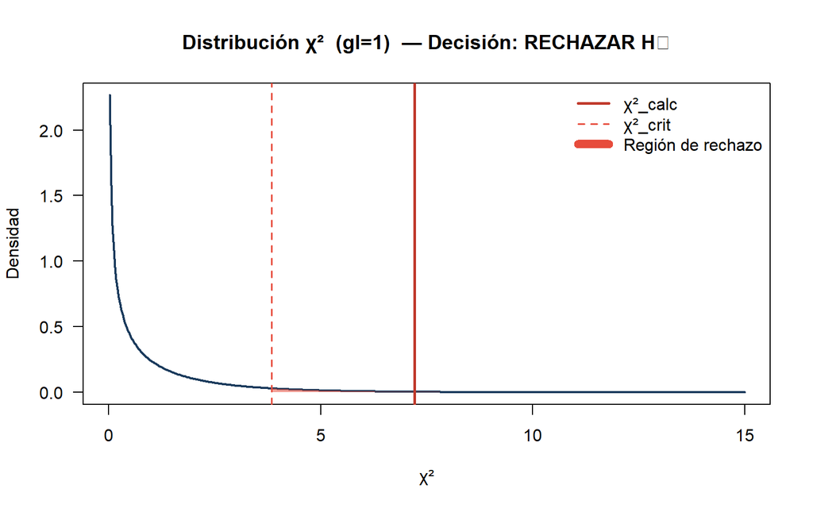

```r
x_chi <- seq(0, max(chi2_c*1.5, chi_cr_c*1.5, 15), length.out=500)
y_chi <- dchisq(x_chi, gl_c)
plot(x_chi, y_chi, type="l", lwd=2, col="#1a3a5c",
     main=paste0("Distribución χ²  (gl=",gl_c,")  — Decisión: ",dec_c),
     xlab="χ²", ylab="Densidad", las=1)
x_rej <- x_chi[x_chi >= chi_cr_c]
polygon(c(x_rej, rev(x_rej)), c(dchisq(x_rej,gl_c), rep(0,length(x_rej))),
        col="#e74c3c88", border=NA)
abline(v=chi2_c, col=if(chi2_c>chi_cr_c)"#c0392b" else "#27ae60", lwd=2.5)
abline(v=chi_cr_c, col="#e74c3c", lwd=1.5, lty=2)
text(chi2_c, max(y_chi)*0.7, paste0("χ²_calc\n",round(chi2_c,3)),
     col="#1a3a5c", font=2, cex=0.85)
legend("topright", legend=c("χ²_calc","χ²_crit","Región de rechazo"),
       col=c(if(chi2_c>chi_cr_c)"#c0392b" else "#27ae60","#e74c3c","#e74c3c"),
       lwd=c(2.5,1.5,8), lty=c(1,2,1), bty="n")
```

## 5.5 Caso 3 — Prueba de homogeneidad

```r
# ─── PARÁMETROS — modifique aquí ─────────────────────────────
mat_hom <- matrix(c(57, 80, 43,
                    57, 58, 20,
                    56, 45, 24,
                    45, 22, 33), nrow=4, byrow=TRUE,
                  dimnames=list(c("Primero","Segundo","Tercero","Cuarto"),
                                c("Curiosidad","Casual","Moderado-Intenso")))
alfa_hom <- 0.05

# ─── CÁLCULOS (mismo procedimiento que contingencia) ──────────
n_hom    <- sum(mat_hom)
esp_hom  <- outer(rowSums(mat_hom), colSums(mat_hom)) / n_hom
chi2_hom <- sum((mat_hom - esp_hom)^2 / esp_hom)
gl_hom   <- (nrow(mat_hom)-1)*(ncol(mat_hom)-1)
chi_cr_hom <- qchisq(1-alfa_hom, gl_hom)
pval_hom <- 1 - pchisq(chi2_hom, gl_hom)
dec_hom  <- if(chi2_hom>chi_cr_hom) "RECHAZAR H₀" else "NO RECHAZAR H₀"

cat("════════════════════════════════════════\n")
```

```
## ════════════════════════════════════════
```

```r
cat("  CHI-CUADRADO — PRUEBA DE HOMOGENEIDAD\n")
```

```
##   CHI-CUADRADO — PRUEBA DE HOMOGENEIDAD
```

```r
cat("════════════════════════════════════════\n")
```

```
## ════════════════════════════════════════
```

```r
print(mat_hom)
```

```
##         Curiosidad Casual Moderado-Intenso
## Primero         57     80               43
## Segundo         57     58               20
## Tercero         56     45               24
## Cuarto          45     22               33
```

```r
cat(sprintf("\n  χ²_calculado = %.4f\n", chi2_hom))
```

```
##
##   χ²_calculado = 23.6729
```

```r
cat(sprintf("  χ²_crítico   = %.4f  (gl=%d)\n", chi_cr_hom, gl_hom))
```

```
##   χ²_crítico   = 12.5916  (gl=6)
```

```r
cat(sprintf("  p-valor      = %.6f\n", pval_hom))
```

```
##   p-valor      = 0.000600
```

```r
cat(sprintf("  DECISIÓN: %s\n", dec_hom))
```

```
##   DECISIÓN: RECHAZAR H₀
```

```r
cat("════════════════════════════════════════\n")
```

```
## ════════════════════════════════════════
```

# 6 REGRESIÓN Y CORRELACIÓN

## 6.1 Teoría

| Concepto | Fórmula |
| --- | --- |
| Pendiente b | $b = \frac{n\sum XY - \sum X\sum Y}{n\sum X^2 - (\sum X)^2}$ |
| Intercepto a | $a = \bar{Y} - b\bar{X}$ |
| Correlación r | $r = \frac{n\sum XY - \sum X\sum Y}{\sqrt{[n\sum X^2-(\sum X)^2][n\sum Y^2-(\sum Y)^2]}}$ |
| Coeficiente de determinación | $R^2 = r^2$ |

## 6.2 Regresión lineal simple

```r
# ─── DATOS — modifique aquí ───────────────────────────────────
X <- c(1,  2,  3,  4,  5,  6,  7,  8,  9, 10)
Y <- c(2.1,3.9,6.2,8.0,9.8,11.9,13.5,15.8,17.3,19.2)
x_pred <- 7.5   # Valor de X para predicción

# ─── CÁLCULOS ─────────────────────────────────────────────────
n_r  <- length(X)
sum_x  <- sum(X);  sum_y  <- sum(Y)
sum_x2 <- sum(X^2); sum_y2 <- sum(Y^2)
sum_xy <- sum(X*Y)
x_bar_r <- mean(X); y_bar_r <- mean(Y)

b_reg <- (n_r*sum_xy - sum_x*sum_y) / (n_r*sum_x2 - sum_x^2)
a_reg <- y_bar_r - b_reg * x_bar_r

r_pearson <- (n_r*sum_xy - sum_x*sum_y) /
             sqrt((n_r*sum_x2-sum_x^2)*(n_r*sum_y2-sum_y^2))
r2_reg <- r_pearson^2

Y_pred <- a_reg + b_reg * X
residuos <- Y - Y_pred
SSE <- sum(residuos^2)
SST <- sum((Y - y_bar_r)^2)
R2_mod <- 1 - SSE/SST

y_new <- a_reg + b_reg * x_pred

fuerza <- ifelse(abs(r_pearson)>=0.9, "Muy fuerte",
          ifelse(abs(r_pearson)>=0.7, "Fuerte",
          ifelse(abs(r_pearson)>=0.5, "Moderada",
          ifelse(abs(r_pearson)>=0.3, "Debil", "Muy debil"))))

cat("════════════════════════════════════════\n")
```

```
## ════════════════════════════════════════
```

```r
cat("  REGRESIÓN LINEAL SIMPLE\n")
```

```
##   REGRESIÓN LINEAL SIMPLE
```

```r
cat("════════════════════════════════════════\n")
```

```
## ════════════════════════════════════════
```

```r
cat(sprintf("  n = %d pares | X̄=%.4f | Ȳ=%.4f\n", n_r, x_bar_r, y_bar_r))
```

```
##   n = 10 pares | X̄=5.5000 | Ȳ=10.7700
```

```r
cat("────────────────────────────────────────\n")
cat("  SUMAS:\n")
```

```
##   SUMAS:
```

```r
cat(sprintf("  ΣX=%.2f | ΣY=%.2f | ΣX²=%.2f\n", sum_x, sum_y, sum_x2))
```

```
##   ΣX=55.00 | ΣY=107.70 | ΣX²=385.00
```

```r
cat(sprintf("  ΣY²=%.2f | ΣXY=%.2f\n", sum_y2, sum_xy))
```

```
##   ΣY²=1459.53 | ΣXY=749.50
```

```r
cat("────────────────────────────────────────\n")
cat("  CORRELACIÓN:\n")
```

```
##   CORRELACIÓN:
```

```r
cat(sprintf("  r = %.6f (%s %s)\n", r_pearson, fuerza,
            ifelse(r_pearson>0, "Positiva", "Negativa")))
```

```
##   r = 0.999576 (Muy fuerte Positiva)
```

```r
cat(sprintf("  r² = %.6f (%.2f%% de variabilidad explicada)\n",
            r2_reg, r2_reg*100))
```

```
##   r² = 0.999152 (99.92% de variabilidad explicada)
```

```r
cat("────────────────────────────────────────\n")
cat("  ECUACIÓN DE REGRESIÓN:\n")
```

```
##   ECUACIÓN DE REGRESIÓN:
```

```r
cat(sprintf("  b = %.6f\n", b_reg))
```

```
##   b = 1.904848
```

```r
cat(sprintf("  a = %.6f\n", a_reg))
```

```
##   a = 0.293333
```

```r
cat(sprintf("  Ŷ = %.4f + %.4f·X\n", a_reg, b_reg))
```

```
##   Ŷ = 0.2933 + 1.9048·X
```

```r
cat("────────────────────────────────────────\n")
cat(sprintf("  R² del modelo = %.4f\n", R2_mod))
```

```
##   R² del modelo = 0.9992
```

```r
cat(sprintf("  SSE = %.4f\n", SSE))
```

```
##   SSE = 0.2541
```

```r
cat("────────────────────────────────────────\n")
cat(sprintf("  PREDICCIÓN: Para X=%.2f → Ŷ=%.4f\n", x_pred, y_new))
```

```
##   PREDICCIÓN: Para X=7.50 → Ŷ=14.5797
```

```r
cat("════════════════════════════════════════\n")
```

```
## ════════════════════════════════════════
```

```r
# Tabla de valores
df_reg <- data.frame(i=1:n_r, X=X, Y=Y,
                     "Ŷ"=round(Y_pred,4),
                     "Residuo (Y-Ŷ)"=round(residuos,4),
                     "(Y-Ŷ)²"=round(residuos^2,4),
                     check.names=FALSE)
knitr::kable(df_reg, caption="Tabla de regresión lineal")
```

Tabla de regresión lineal

| i | X | Y | Ŷ | Residuo (Y-Ŷ) | (Y-Ŷ)² |
| --- | --- | --- | --- | --- | --- |
| 1 | 1 | 2.1 | 2.1982 | -0.0982 | 0.0096 |
| 2 | 2 | 3.9 | 4.1030 | -0.2030 | 0.0412 |
| 3 | 3 | 6.2 | 6.0079 | 0.1921 | 0.0369 |
| 4 | 4 | 8.0 | 7.9127 | 0.0873 | 0.0076 |
| 5 | 5 | 9.8 | 9.8176 | -0.0176 | 0.0003 |
| 6 | 6 | 11.9 | 11.7224 | 0.1776 | 0.0315 |
| 7 | 7 | 13.5 | 13.6273 | -0.1273 | 0.0162 |
| 8 | 8 | 15.8 | 15.5321 | 0.2679 | 0.0718 |
| 9 | 9 | 17.3 | 17.4370 | -0.1370 | 0.0188 |
| 10 | 10 | 19.2 | 19.3418 | -0.1418 | 0.0201 |

## 6.3 Gráfico de regresión

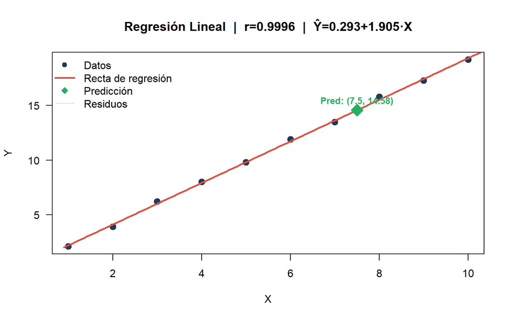

```r
x_line <- seq(min(X)*0.9, max(X)*1.1, length.out=200)
y_line <- a_reg + b_reg * x_line

plot(X, Y, pch=19, col="#1a3a5c", cex=1.3,
     main=paste0("Regresión Lineal  |  r=",round(r_pearson,4),
                 "  |  Ŷ=",round(a_reg,3),"+",round(b_reg,3),"·X"),
     xlab="X", ylab="Y", las=1)
lines(x_line, y_line, col="#e74c3c", lwd=2.5)
points(x_pred, y_new, pch=23, bg="#27ae60", col="#27ae60", cex=2)
text(x_pred, y_new, paste0("Pred: (",x_pred,", ",round(y_new,2),")"),
     pos=3, col="#27ae60", font=2, cex=0.85)
for(i in 1:n_r)
  segments(X[i], Y[i], X[i], Y_pred[i], col="#e74c3c44", lwd=1)
legend("topleft", legend=c("Datos","Recta de regresión","Predicción","Residuos"),
       col=c("#1a3a5c","#e74c3c","#27ae60","#e74c3c44"),
       pch=c(19,NA,23,NA), lwd=c(NA,2.5,NA,1),
       pt.bg=c(NA,NA,"#27ae60",NA), bty="n")
```

## 6.4 Regresión múltiple y no lineal

```r
# ─── REGRESIÓN CUADRÁTICA (NO LINEAL) ────────────────────────
X2 <- c(1, 2, 3, 4, 5, 6, 7)
Y2 <- c(3, 8, 15, 24, 35, 48, 63)

# Ajuste cuadrático
fit_cuad <- lm(Y2 ~ poly(X2, 2, raw=TRUE))
coef_cuad <- coef(fit_cuad)

cat("════════════════════════════════════════\n")
```

```
## ════════════════════════════════════════
```

```r
cat("  REGRESIÓN CUADRÁTICA (NO LINEAL)\n")
```

```
##   REGRESIÓN CUADRÁTICA (NO LINEAL)
```

```r
cat("════════════════════════════════════════\n")
```

```
## ════════════════════════════════════════
```

```r
cat(sprintf("  Ŷ = %.4f + %.4f·X + %.4f·X²\n",
            coef_cuad[1], coef_cuad[2], coef_cuad[3]))
```

```
##   Ŷ = -0.0000 + 2.0000·X + 1.0000·X²
```

```r
cat(sprintf("  R² = %.4f\n", summary(fit_cuad)$r.squared))
```

```
##   R² = 1.0000
```

```r
cat("════════════════════════════════════════\n")
```

```
## ════════════════════════════════════════
```

```r
# ─── REGRESIÓN MÚLTIPLE ───────────────────────────────────────
# Ejemplo: Y depende de X1 y X2
X1_m <- c(10, 20, 30, 40, 50, 60, 70)
X2_m <- c(5,  8, 12, 14, 18, 20, 25)
Y_m  <- c(22, 38, 58, 74, 92, 110, 135)

fit_mult <- lm(Y_m ~ X1_m + X2_m)
coef_m   <- coef(fit_mult)

cat("════════════════════════════════════════\n")
```

```
## ════════════════════════════════════════
```

```r
cat("  REGRESIÓN MÚLTIPLE: Y = a + b₁X₁ + b₂X₂\n")
```

```
##   REGRESIÓN MÚLTIPLE: Y = a + b₁X₁ + b₂X₂
```

```r
cat("════════════════════════════════════════\n")
```

```
## ════════════════════════════════════════
```

```r
cat(sprintf("  a  = %.4f\n", coef_m[1]))
```

```
##   a  = -3.1765
```

```r
cat(sprintf("  b₁ = %.4f (coef. de X₁)\n", coef_m[2]))
```

```
##   b₁ = 0.9294 (coef. de X₁)
```

```r
cat(sprintf("  b₂ = %.4f (coef. de X₂)\n", coef_m[3]))
```

```
##   b₂ = 2.8529 (coef. de X₂)
```

```r
cat(sprintf("  R² = %.4f\n", summary(fit_mult)$r.squared))
```

```
##   R² = 0.9985
```

```r
cat(sprintf("  R ajustado = %.4f\n", summary(fit_mult)$adj.r.squared))
```

```
##   R ajustado = 0.9978
```

```r
cat("════════════════════════════════════════\n")
```

```
## ════════════════════════════════════════
```

# 7 MUESTREO ESTADÍSTICO

## 7.2 Muestreo aleatorio simple

```r
# ─── PARÁMETROS — modifique aquí ─────────────────────────────
N_pob <- 500   # Tamaño de la población
n_mues <- 50   # Tamaño de la muestra
semilla <- 42  # Semilla para reproducibilidad

set.seed(semilla)
muestra_simple <- sort(sample(1:N_pob, n_mues))

cat("════════════════════════════════════════\n")
```

```
## ════════════════════════════════════════
```

```r
cat("  MUESTREO ALEATORIO SIMPLE\n")
```

```
##   MUESTREO ALEATORIO SIMPLE
```

```r
cat("════════════════════════════════════════\n")
```

```
## ════════════════════════════════════════
```

```r
cat(sprintf("  N = %d | n = %d | f = n/N = %.4f\n",
            N_pob, n_mues, n_mues/N_pob))
```

```
##   N = 500 | n = 50 | f = n/N = 0.1000
```

```r
cat("  Elementos seleccionados:\n")
```

```
##   Elementos seleccionados:
```

```r
cat(paste(muestra_simple, collapse=", "), "\n")
```

```
## 4, 5, 20, 24, 49, 74, 89, 109, 110, 122, 128, 136, 146, 153, 158, 165, 197, 212, 226, 228, 259, 283, 292, 297, 298, 299, 303, 314, 321, 324, 327, 348, 356, 360, 367, 370, 387, 399, 406, 410, 418, 420, 467, 470, 474, 485, 486, 489, 494, 500
```

```r
cat("════════════════════════════════════════\n")
```

```
## ════════════════════════════════════════
```

## 7.3 Muestreo estratificado proporcional

```r
# ─── PARÁMETROS — modifique aquí ─────────────────────────────
n_total_est  <- 100  # Muestra total deseada
estratos_nom <- c("Estrato A", "Estrato B", "Estrato C")
N_estratos   <- c(200, 350, 150)  # Tamaño de cada estrato

N_pob_est <- sum(N_estratos)
n_i <- round(n_total_est * N_estratos / N_pob_est)

df_est <- data.frame(
  Estrato = estratos_nom,
  "Nᵢ (Población)" = N_estratos,
  "Proporción Nᵢ/N" = round(N_estratos/N_pob_est, 4),
  "nᵢ (Muestra)" = n_i,
  check.names = FALSE
)

cat("════════════════════════════════════════\n")
```

```
## ════════════════════════════════════════
```

```r
cat("  MUESTREO ESTRATIFICADO PROPORCIONAL\n")
```

```
##   MUESTREO ESTRATIFICADO PROPORCIONAL
```

```r
cat("════════════════════════════════════════\n")
```

```
## ════════════════════════════════════════
```

```r
cat(sprintf("  N_total = %d | n_total = %d\n", N_pob_est, n_total_est))
```

```
##   N_total = 700 | n_total = 100
```

```r
cat(sprintf("  Fórmula: nᵢ = n_total × Nᵢ/N\n"))
```

```
##   Fórmula: nᵢ = n_total × Nᵢ/N
```

```r
cat("════════════════════════════════════════\n")
```

```
## ════════════════════════════════════════
```

```r
knitr::kable(df_est, caption="Distribución de la muestra por estratos")
```

Distribución de la muestra por estratos

| Estrato | Nᵢ (Población) | Proporción Nᵢ/N | nᵢ (Muestra) |
| --- | --- | --- | --- |
| Estrato A | 200 | 0.2857 | 29 |
| Estrato B | 350 | 0.5000 | 50 |
| Estrato C | 150 | 0.2143 | 21 |

## 7.4 Muestreo sistemático

```r
# ─── PARÁMETROS — modifique aquí ─────────────────────────────
N_sist  <- 200   # Tamaño población
n_sist  <- 20    # Tamaño muestra
k0_sist <- 3     # Punto de inicio

k_intervalo <- floor(N_sist / n_sist)
elementos_sist <- seq(k0_sist, by=k_intervalo, length.out=n_sist)
elementos_sist <- elementos_sist[elementos_sist <= N_sist]

cat("════════════════════════════════════════\n")
```

```
## ════════════════════════════════════════
```

```r
cat("  MUESTREO SISTEMÁTICO\n")
```

```
##   MUESTREO SISTEMÁTICO
```

```r
cat("════════════════════════════════════════\n")
```

```
## ════════════════════════════════════════
```

```r
cat(sprintf("  N=%d | n=%d | k=N/n=%d | k₀=%d\n",
            N_sist, n_sist, k_intervalo, k0_sist))
```

```
##   N=200 | n=20 | k=N/n=10 | k₀=3
```

```r
cat(sprintf("  Patrón: k₀, k₀+k, k₀+2k, ...\n"))
```

```
##   Patrón: k₀, k₀+k, k₀+2k, ...
```

```r
cat("  Elementos seleccionados:\n")
```

```
##   Elementos seleccionados:
```

```r
cat(paste(elementos_sist, collapse=", "), "\n")
```

```
## 3, 13, 23, 33, 43, 53, 63, 73, 83, 93, 103, 113, 123, 133, 143, 153, 163, 173, 183, 193
```

```r
cat("════════════════════════════════════════\n")
```

```
## ════════════════════════════════════════
```

## 7.5 Determinación del tamaño de muestra

```r
# ─── PARA ESTIMAR UNA MEDIA ───────────────────────────────────
sigma_tm  <- 15    # Desviación estándar estimada
E_media   <- 3     # Error máximo tolerable
alfa_tm   <- 0.05  # Nivel de significación
Z_tm      <- qnorm(1 - alfa_tm/2)
n_media_calc <- ceiling((Z_tm * sigma_tm / E_media)^2)

# ─── PARA ESTIMAR UNA PROPORCIÓN ─────────────────────────────
p_tm  <- 0.5    # Proporción estimada (0.5 = máxima varianza)
q_tm  <- 1 - p_tm
E_prop <- 0.05   # Error máximo tolerable
alfa_p <- 0.05
Z_tp   <- qnorm(1 - alfa_p/2)
n_prop_calc <- ceiling(Z_tp^2 * p_tm * q_tm / E_prop^2)

cat("════════════════════════════════════════\n")
```

```
## ════════════════════════════════════════
```

```r
cat("  DETERMINACIÓN DEL TAMAÑO DE MUESTRA\n")
```

```
##   DETERMINACIÓN DEL TAMAÑO DE MUESTRA
```

```r
cat("════════════════════════════════════════\n")
```

```
## ════════════════════════════════════════
```

```r
cat("  PARA ESTIMAR UNA MEDIA:\n")
```

```
##   PARA ESTIMAR UNA MEDIA:
```

```r
cat(sprintf("  n = (Z·σ/E)² = (%.4f·%.4f/%.4f)²\n", Z_tm, sigma_tm, E_media))
```

```
##   n = (Z·σ/E)² = (1.9600·15.0000/3.0000)²
```

```r
cat(sprintf("  n = %.2f → n = %d\n", (Z_tm*sigma_tm/E_media)^2, n_media_calc))
```

```
##   n = 96.04 → n = 97
```

```r
cat("────────────────────────────────────────\n")
cat("  PARA ESTIMAR UNA PROPORCIÓN:\n")
```

```
##   PARA ESTIMAR UNA PROPORCIÓN:
```

```r
cat(sprintf("  n = Z²·p·q/E² = %.4f²·%.2f·%.2f/%.4f²\n",
            Z_tp, p_tm, q_tm, E_prop))
```

```
##   n = Z²·p·q/E² = 1.9600²·0.50·0.50/0.0500²
```

```r
cat(sprintf("  n = %.2f → n = %d\n",
            Z_tp^2*p_tm*q_tm/E_prop^2, n_prop_calc))
```

```
##   n = 384.15 → n = 385
```

```r
cat("════════════════════════════════════════\n")
```

```
## ════════════════════════════════════════
```

## 7.6 Gráfico: relación Error vs Tamaño de muestra

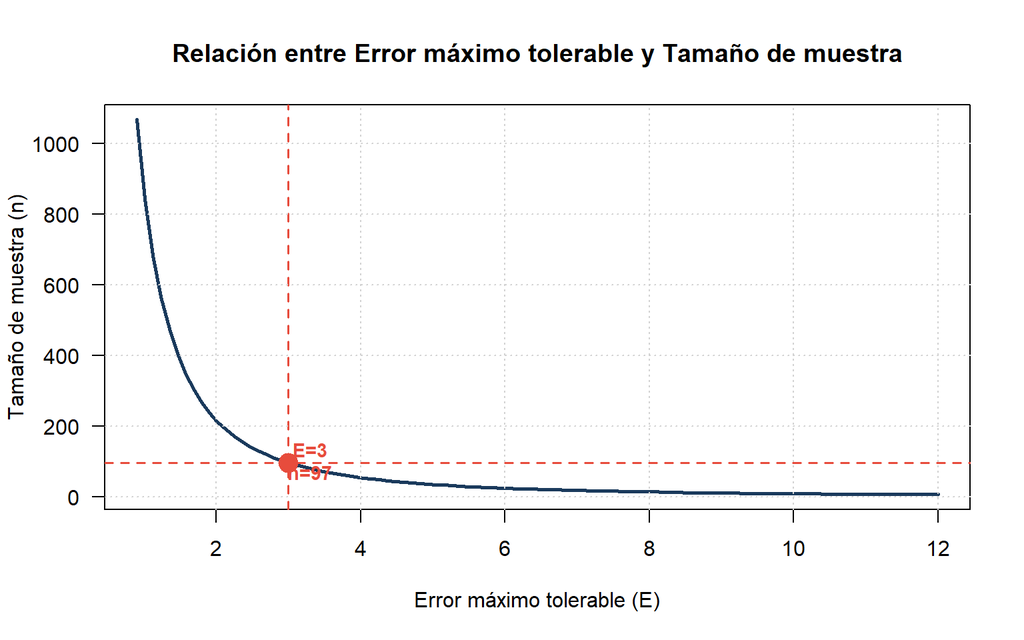

```r
E_rango <- seq(E_media*0.3, E_media*4, length.out=100)
n_rango <- ceiling((Z_tm * sigma_tm / E_rango)^2)

plot(E_rango, n_rango, type="l", lwd=2.5, col="#1a3a5c",
     main="Relación entre Error máximo tolerable y Tamaño de muestra",
     xlab="Error máximo tolerable (E)", ylab="Tamaño de muestra (n)", las=1)
abline(v=E_media, col="#e74c3c", lty=2, lwd=1.5)
abline(h=n_media_calc, col="#e74c3c", lty=2, lwd=1.5)
points(E_media, n_media_calc, pch=19, col="#e74c3c", cex=2)
text(E_media*1.1, n_media_calc*1.05,
     paste0("E=",E_media,"\nn=",n_media_calc),
     col="#e74c3c", font=2, cex=0.9)
grid()
```

# 8 TABLAS DE REFERENCIA

```r
# ─── TABLA DE VALORES CRÍTICOS Z ──────────────────────────────
alfas_ref <- c(0.10, 0.05, 0.025, 0.01, 0.005)
tab_z <- data.frame(
  "α (bilateral)" = c(0.20,0.10,0.05,0.02,0.01),
  "α/2" = alfas_ref,
  "Z_α (cola derecha)" = round(qnorm(1-alfas_ref),4),
  "±Z_α/2 (bilateral)" = round(qnorm(1-alfas_ref/2),4),
  check.names=FALSE
)
knitr::kable(tab_z, caption="Valores críticos Z más usados")
```

Valores críticos Z más usados

| α (bilateral) | α/2 | Z_α (cola derecha) | ±Z_α/2 (bilateral) |
| --- | --- | --- | --- |
| 0.20 | 0.100 | 1.2816 | 1.6449 |
| 0.10 | 0.050 | 1.6449 | 1.9600 |
| 0.05 | 0.025 | 1.9600 | 2.2414 |
| 0.02 | 0.010 | 2.3263 | 2.5758 |
| 0.01 | 0.005 | 2.5758 | 2.8070 |

```r
# ─── TABLA DE VALORES CRÍTICOS CHI-CUADRADO ───────────────────
gls_ref <- 1:15
tab_chi <- data.frame(
  gl = gls_ref,
  "χ²_0.10" = round(qchisq(0.90,gls_ref),3),
  "χ²_0.05" = round(qchisq(0.95,gls_ref),3),
  "χ²_0.025"= round(qchisq(0.975,gls_ref),3),
  "χ²_0.01" = round(qchisq(0.99,gls_ref),3),
  "χ²_0.005"= round(qchisq(0.995,gls_ref),3),
  check.names=FALSE
)
knitr::kable(tab_chi, caption="Valores críticos χ² por grados de libertad")
```

Valores críticos χ² por grados de libertad

| gl | χ²_0.10 | χ²_0.05 | χ²_0.025 | χ²_0.01 | χ²_0.005 |
| --- | --- | --- | --- | --- | --- |
| 1 | 2.706 | 3.841 | 5.024 | 6.635 | 7.879 |
| 2 | 4.605 | 5.991 | 7.378 | 9.210 | 10.597 |
| 3 | 6.251 | 7.815 | 9.348 | 11.345 | 12.838 |
| 4 | 7.779 | 9.488 | 11.143 | 13.277 | 14.860 |
| 5 | 9.236 | 11.070 | 12.833 | 15.086 | 16.750 |
| 6 | 10.645 | 12.592 | 14.449 | 16.812 | 18.548 |
| 7 | 12.017 | 14.067 | 16.013 | 18.475 | 20.278 |
| 8 | 13.362 | 15.507 | 17.535 | 20.090 | 21.955 |
| 9 | 14.684 | 16.919 | 19.023 | 21.666 | 23.589 |
| 10 | 15.987 | 18.307 | 20.483 | 23.209 | 25.188 |
| 11 | 17.275 | 19.675 | 21.920 | 24.725 | 26.757 |
| 12 | 18.549 | 21.026 | 23.337 | 26.217 | 28.300 |
| 13 | 19.812 | 22.362 | 24.736 | 27.688 | 29.819 |
| 14 | 21.064 | 23.685 | 26.119 | 29.141 | 31.319 |
| 15 | 22.307 | 24.996 | 27.488 | 30.578 | 32.801 |

```r
# ─── TABLA DE VALORES t ───────────────────────────────────────
gls_t <- c(5,10,15,20,25,30,40,60,120,200)
tab_t <- data.frame(
  gl = gls_t,
  "t_0.10" = round(qt(0.90, gls_t),4),
  "t_0.05" = round(qt(0.95, gls_t),4),
  "t_0.025"= round(qt(0.975,gls_t),4),
  "t_0.01" = round(qt(0.99, gls_t),4),
  check.names=FALSE
)
knitr::kable(tab_t, caption="Valores críticos t de Student")
```

Valores críticos t de Student

| gl | t_0.10 | t_0.05 | t_0.025 | t_0.01 |
| --- | --- | --- | --- | --- |
| 5 | 1.4759 | 2.0150 | 2.5706 | 3.3649 |
| 10 | 1.3722 | 1.8125 | 2.2281 | 2.7638 |
| 15 | 1.3406 | 1.7531 | 2.1314 | 2.6025 |
| 20 | 1.3253 | 1.7247 | 2.0860 | 2.5280 |
| 25 | 1.3163 | 1.7081 | 2.0595 | 2.4851 |
| 30 | 1.3104 | 1.6973 | 2.0423 | 2.4573 |
| 40 | 1.3031 | 1.6839 | 2.0211 | 2.4233 |
| 60 | 1.2958 | 1.6706 | 2.0003 | 2.3901 |
| 120 | 1.2886 | 1.6577 | 1.9799 | 2.3578 |
| 200 | 1.2858 | 1.6525 | 1.9719 | 2.3451 |

# 9 INSTRUCCIONES DE USO

1. **Instale los paquetes** necesarios (solo una vez):

   ```r
   install.packages(c("rmarkdown", "knitr", "ggplot2"))
   ```

2. **Para generar el reporte HTML:** En RStudio, abra este archivo `.Rmd` y haga clic en **“Knit”** → **“Knit to HTML”**.
3. **Para modificar cualquier ejercicio:** Cambie únicamente los valores en las secciones marcadas con `# ─── PARÁMETROS — modifique aquí ───`.
4. **Para correr la aplicación Shiny** (archivo `app.R`):

   ```r
   shiny::runApp("app.R")
   ```

*Propuesta Aplicativa — IS-241 Estadística Inferencial | UNADECA | 2026*